# koiplot

Richard Vale* [(return to homepage)](https://rtrvale.github.io)

2017-03-23

### Introduction

The koiplot package produces scatterplots in which points are replaced by decorated rectangles called brushstrokes. Various parameters of the brushstrokes can be adjusted to plot extra variables in the data set, in a similar way to a balloon plot. Although the koiplot can be viewed as an enhanced scatterplot, its main use is not as a way of displaying data but as a way of producing artistic-looking graphics which could be used, for example, on the cover of a report.

The graphics in this document are just for illustrative purposes; the choice of variables plotted is not supposed to be especially meaningful.

First, here are Anderson’s iris data.

```
## Default choices of columns to be plotted:
## x: Sepal.Length
## y: Sepal.Width
## angle:  Petal.Length
## colour: Species
```

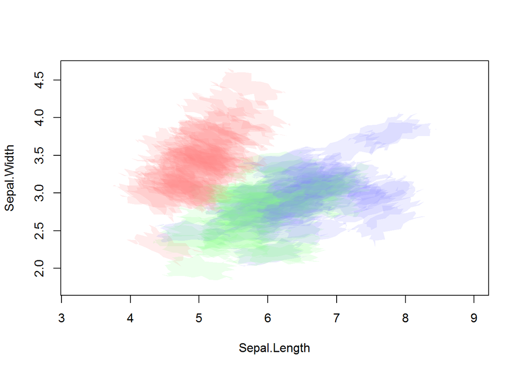

```r
# koiplot
koiplot(iris)
```

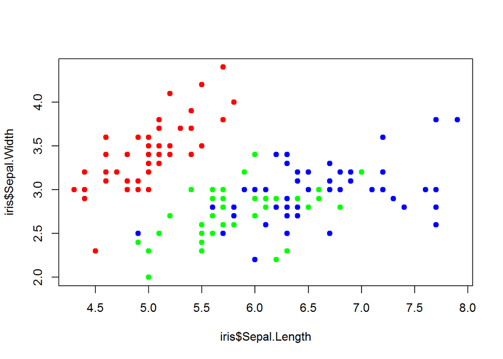

```r
# scatterplot
plot(iris$Sepal.Length, iris$Sepal.Width, col=c("red","green","blue")[as.factor(iris$Species)],pch=19)
```

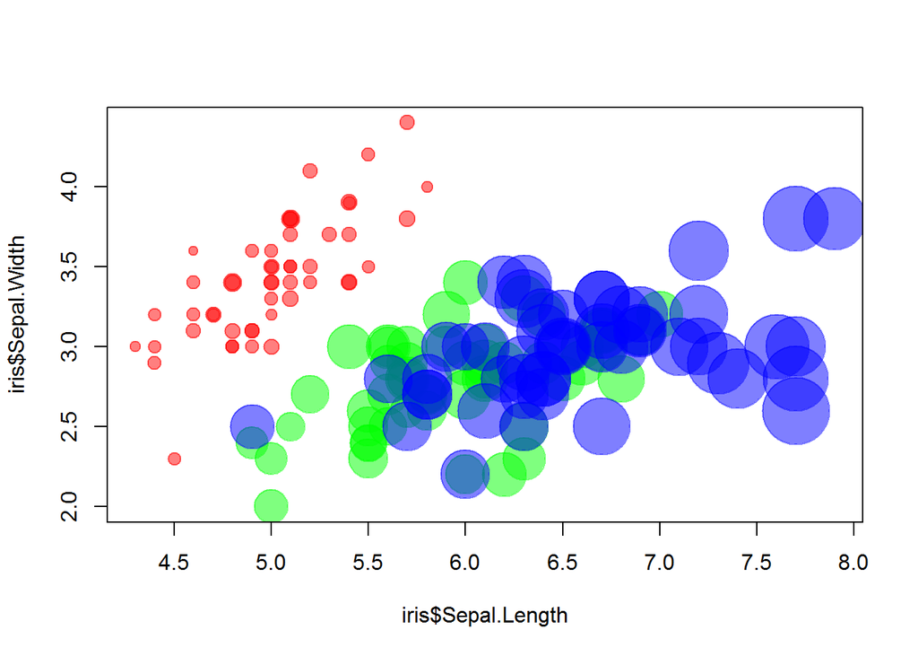

```r
# balloon plot
plot(iris$Sepal.Length, iris$Sepal.Width, col=c(rgb(1,0,0,0.5),rgb(0,1,0,0.5),rgb(0,0,1,0.5))[as.factor(iris$Species)],pch=19, cex=iris$Petal.Length)
```

### Brushstrokes

The individual brushstrokes in a koiplot are rectangles produced using the `polygon` function. The rectangle is centered at the coordinates `(x, y)`. Here is a rectangle centered at `(0,0)` with a width of `2` and a height of `1`.

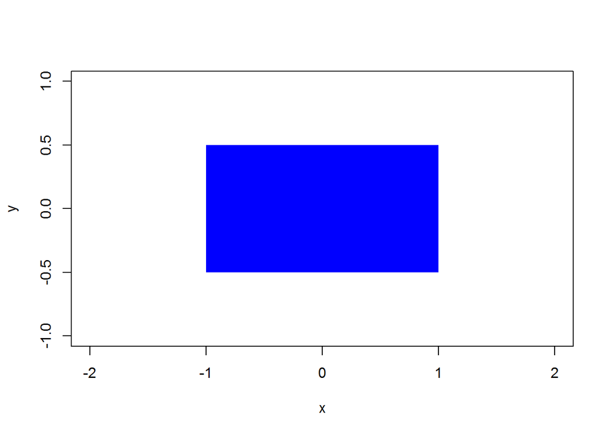

```r
plot(0, 0, type="n", xlim=c(-2,2), ylim=c(-1,1), xlab="x", ylab="y")
brushstroke(x=0, y=0, width=2, height=1, xnoise=0, ynoise=0, curvature=0)
```

The `angle` argument can be used to adjust the angle (in radians) the rectangle makes with the positive x-axis.

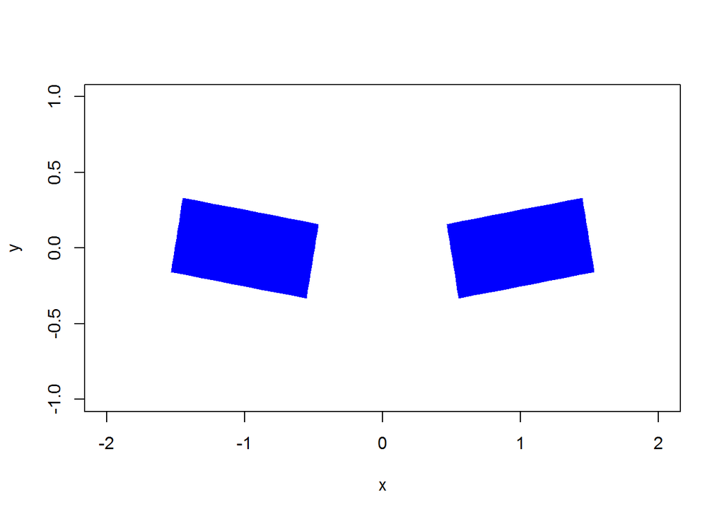

```r
plot(0, 0, type="n", xlim=c(-2,2), ylim=c(-1,1), xlab="x", ylab="y")
brushstroke(x=-1, y=0, width=1, height=0.5, xnoise=0, ynoise=0, curvature=0, angle=-10*pi/180)
brushstroke(x=1, y=0, width=1, height=0.5, xnoise=0, ynoise=0, curvature=0, angle=10*pi/180)
```

The `xnoise` and `ynoise` arguments add noise in the x- and y-direction respectively.

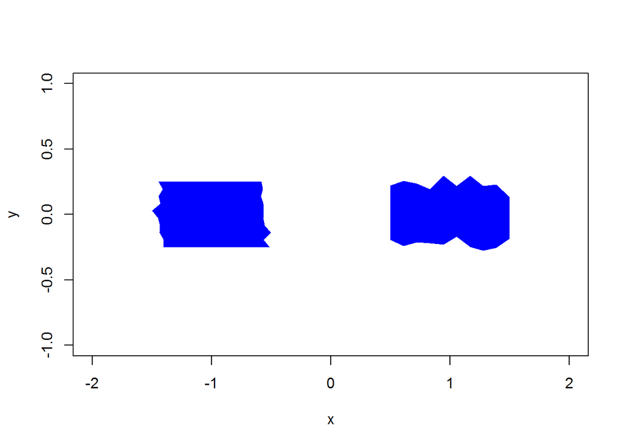

```r
plot(x=0, y=0, type="n", xlim=c(-2,2), ylim=c(-1,1), xlab="x", ylab="y")
brushstroke(x=-1, y=0, width=1, height=0.5, xnoise=0.1, ynoise=0, curvature=0)
brushstroke(x=1, y=0, width=1, height=0.5, xnoise=0, ynoise=0.05, curvature=0)
```

The `curvature` argument adds positive or negative curvature which helps the brushstroke look more natural. When adding large amounts of curvature, it is better to set `xnoise` to zero or else the brushstrokes will look ugly.

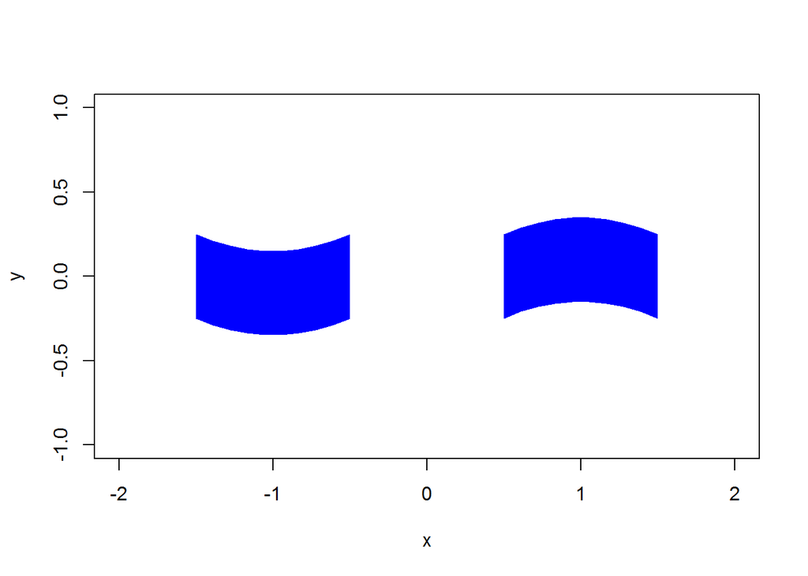

```r
plot(x=0, y=0, type="n", xlim=c(-2,2), ylim=c(-1,1), xlab="x", ylab="y")
brushstroke(x=-1, y=0, width=1, height=0.5, xnoise=0, ynoise=0, curvature=0.1)
brushstroke(x=1, y=0, width=1, height=0.5, xnoise=0, ynoise=0, curvature=-0.1)
```

The `xstrectch` and `ystretch` arguments can be used to adjust the brushstrokes to avoid distortion caused by the aspect ratio of the plot not being 1:1. Compare the two plots below.

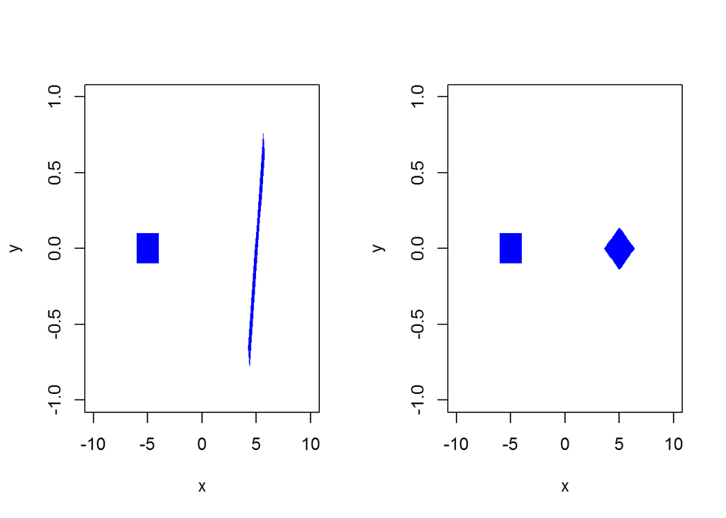

```r
par(mfrow=c(1,2))

# distorted-looking brushstroke
plot(0, 0, xlim=c(-10, 10), ylim=c(-1, 1), type="n", xlab="x", ylab="y")
brushstroke(-5, 0, width=2, height=0.2, angle=0, xnoise=0, ynoise=0, curvature=0)
brushstroke(5, 0, width=2, height=0.2, angle=45*pi/180, xnoise=0, ynoise=0, curvature=0)

# find the aspect ratio of the plot which has just been made
usr <- par("usr")
xstretch <- usr[2] - usr[1]
ystretch <- usr[4] - usr[3]

# distortion corrected using xstretch and ystretch
plot(0, 0, xlim=c(-10, 10), ylim=c(-1, 1), type="n", xlab="x", ylab="y")
brushstroke(-5, 0, width=2, height=0.2, angle=0, xnoise=0, ynoise=0, curvature=0)
brushstroke(5, 0, width=2, height=0.2, angle=45*pi/180, xnoise=0, ynoise=0, xstretch=xstretch, ystretch=ystretch, curvature=0)
```

### The koiplot function

The main function of the package is `koiplot`. This function is a wrapper for the lower-level function `koiplotxy`, which does the actual plotting.

#### Plotting a data frame

If a data frame is passed to `koiplot` with no other arguments, the function will select the columns to be plotted and print its choices to the console, as in `koiplot(iris)`. The `x` variable will be the first numeric column encountered from the left and the `y` variable will be the second numeric column. The angle will be the third numeric column if there is one. Angles are rescaled into the range -45 degrees to 45 degrees. Colours are selected by finding a factor or character column (the one with the fewest distinct values is used). The transparency value for the colours is `0.1` by default.

In the case of a data frame with over 10000 rows, 10000 rows are selected at random for plotting (otherwise the plotting process may be very slow.)

This function attempts to make a very quick and basic plot. Obviously it doesn’t always work well. For example, if the data frame has a numeric index in its first column, then this will be selected as the first variable, as in the following example using the crabs data of Campbell and Mahon from the `MASS` package.

```
## Default choices of columns to be plotted:
## x: index
## y: FL
## angle:  RW
## colour: sp
```

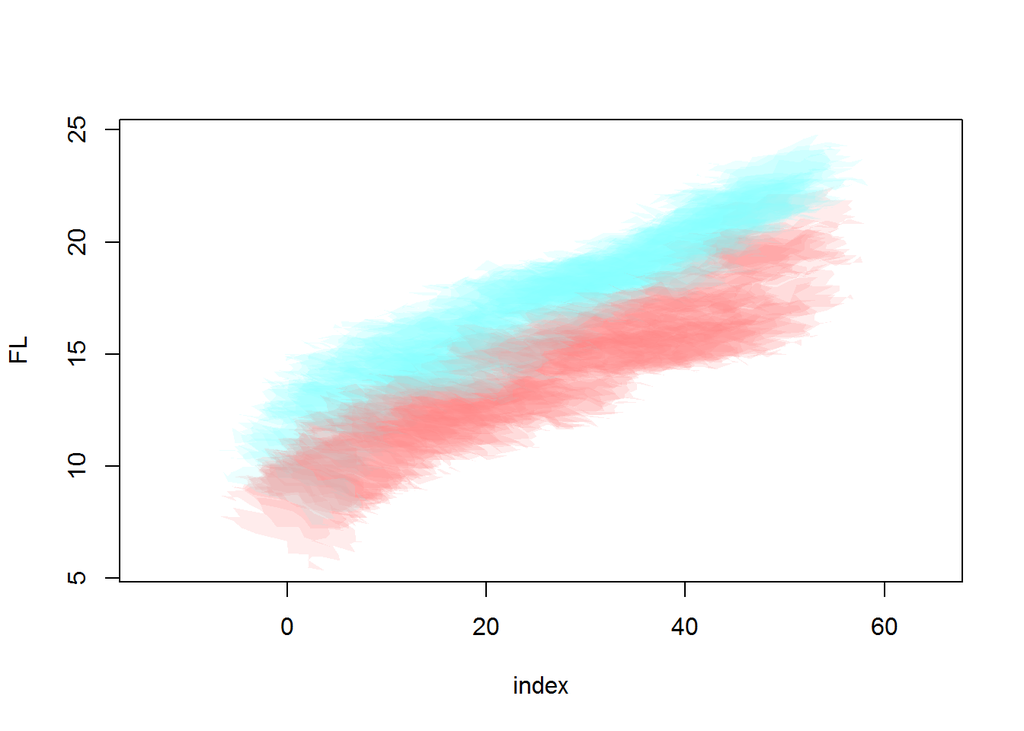

```r
library(MASS)
koiplot(crabs)
```

Extra arguments can be passed to the `koiplot` function. For example, to omit the axes, border and add a title.

```
## Default choices of columns to be plotted:
## x: index
## y: FL
## angle:  RW
## colour: sp
```

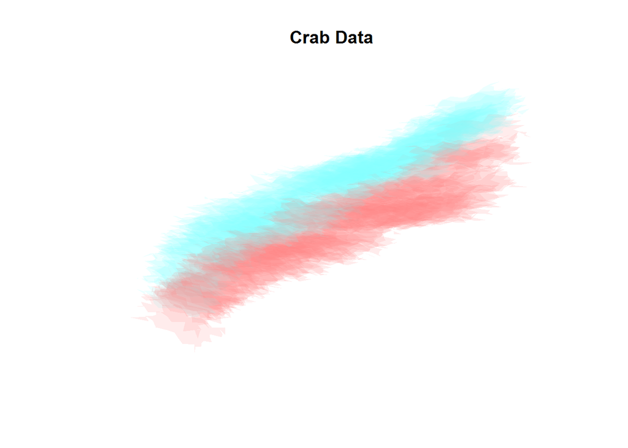

```r
koiplot(crabs, xaxt="n", yaxt="n", xlab="", ylab="", bty="n", main="Crab Data")
```

#### Plotting a pair of vectors

Instead of a data frame, vectors `x` and `y` can be passed to the `koiplot` function, and this is usually preferable. For example, in the crab data, suppose that we want to plot carapace length and rear width. The variable `cols` can be used to specify the colour column.

*Caution! Do not confuse `cols` with `col`. The latter is also a valid argument to `koiplot` but it will be passed to the `plot` function and will do nothing!*

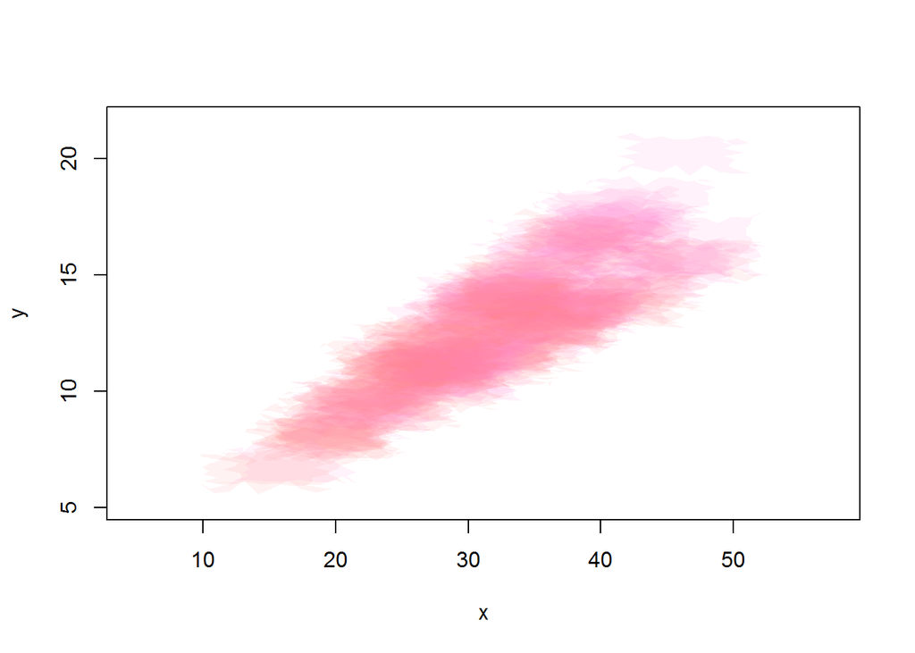

```r
koiplot(crabs$CL, crabs$RW, cols=crabs$sp)
```

This plot can be enhanced by adding an angle variable and forming the colours from the `(sex, sp)` pairs.

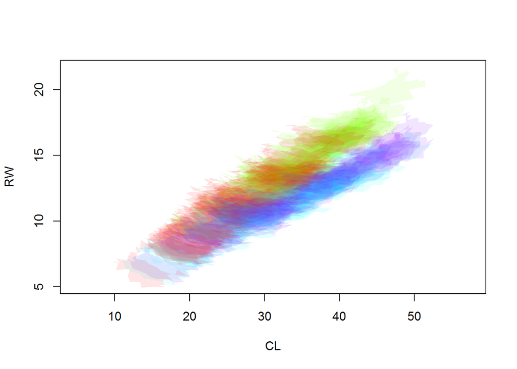

```r
koiplot(crabs$CL, crabs$RW, angle=crabs$FL, cols=rainbow(4)[as.factor(paste0(crabs$sex, crabs$sp))], curvature=0.5, xlab="CL", ylab="RW")
```

The following plot shows the result of performing PCA and including other optional arguments to `koiplot` including arguments to `plot`.

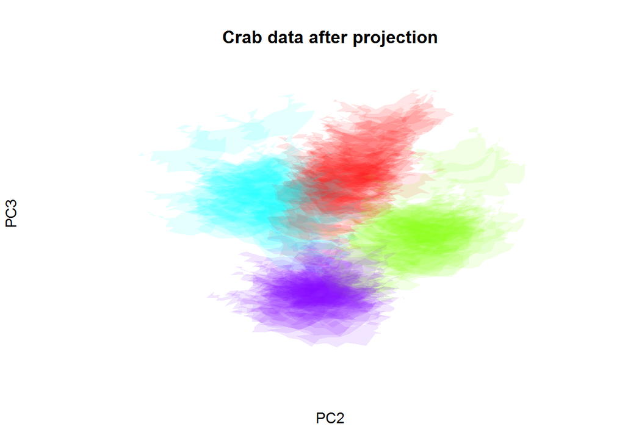

```r
out <- prcomp(crabs[,-c(1:3)])
koiplot(out$x[,2], out$x[,3], angle=out$x[,1], cols=rainbow(4)[as.factor(paste0(crabs$sex, crabs$sp))], curvature=0.25, xaxt="n", yaxt="n", xlab="PC2", ylab="PC3", main="Crab data after projection", bty="n")
```

#### Transparency

By default, the alpha value for the colours in `koiplot` is 0.1. The variable `alpha` can be specified as a vector containing the alpha values for the individual brushstrokes, but usually it will just be given as a single number.

A value of `alpha` less than 1 is generally advisable, as this can help the viewer to see which regions of the plot are relatively dense.

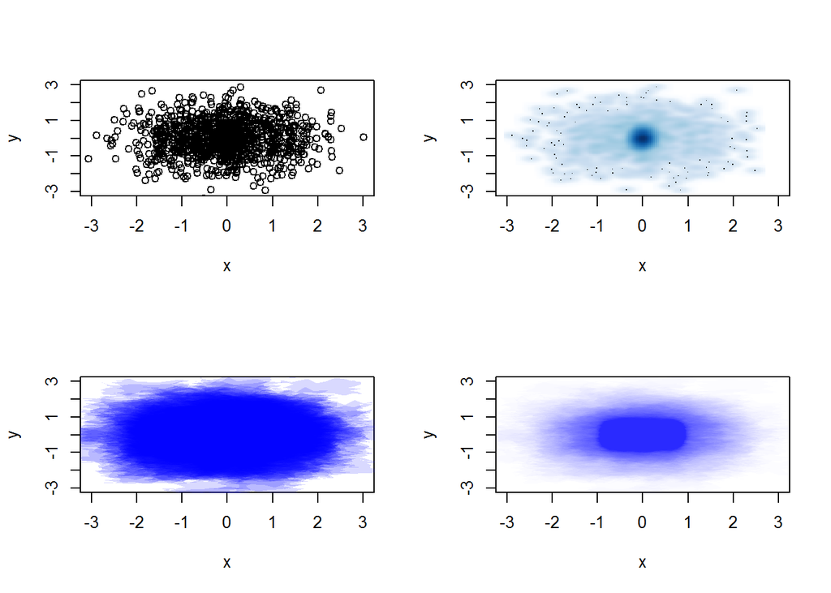

```r
x <- data.frame(x=c(rnorm(1000), rnorm(1000, 0, 0.1)), y=c(rnorm(1000), rnorm(1000, 0, 0.3)))

par(mfrow=c(2,2))
xlim <- ylim <- c(-3,3)

plot(x, xlim=xlim, ylim=ylim)
smoothScatter(x, xlim=xlim, ylim=ylim)
koiplot(x, xlim=xlim, ylim=ylim)
koiplot(x, alpha=0.01, xlim=xlim, ylim=ylim)
```

#### Colours

It is possible to specify a numeric vector as the `cols` argument. This will be converted to a vector of rainbow colours in such a way that points with nearby values of the cols argument will have similar colours.

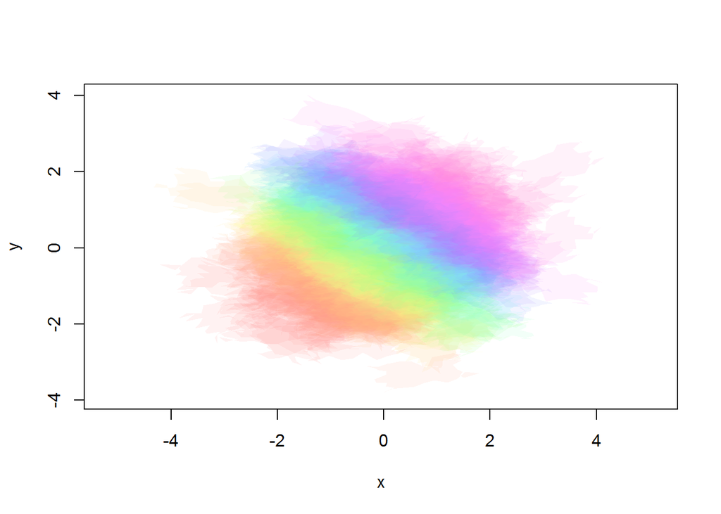

```r
x <- rnorm(1000)
y <- rnorm(1000)
koiplot(x, y, cols=x+y, angle=runif(1000)*2*pi)
```

#### Dealing with angles

When an angle variable is specified, the angles are rescaled into the range -45 degrees to 45 degrees by default. This can be changed using `min_angle` and `max_angle`. For example, compare the ouput of `koiplot(iris)` to the following.

```
## Default choices of columns to be plotted:
## x: Sepal.Length
## y: Sepal.Width
## angle:  Petal.Length
## colour: Species
```

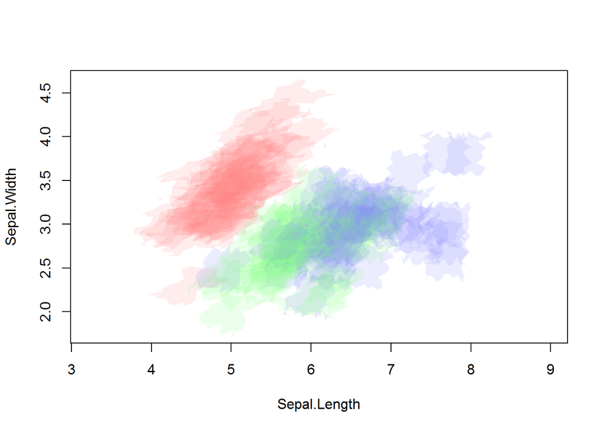

```r
koiplot(iris, min_angle=45, max_angle=90)
```

When a variable takes values in the circle, such as day of the week, it may not be desirable to rescale angles like this. In this case, `koiplot` can be called with `rescale_angles=F` and the angles can be specified by the user.

For example, in the [bike sharing dataset](https://archive.ics.uci.edu/ml/datasets/Bike+Sharing+Dataset) from the UCI Machine Learning Respository, the variable `hr` is the hour of the day (in the range 0-23.) Loading the data frame `hours.csv` into R as an object `bike`, we can define the angle for the brushstrokes to be horizontal when `hr = 11.5` and vertical when `hr = 0`.

```r
angle <- ((bike$hr-11.5)/11.5)*pi/2
```

Here, we use the `month` variable to define the colour of the brushstrokes.

```
## Choosing 10000 random rows. Change nmax to plot more rows
```

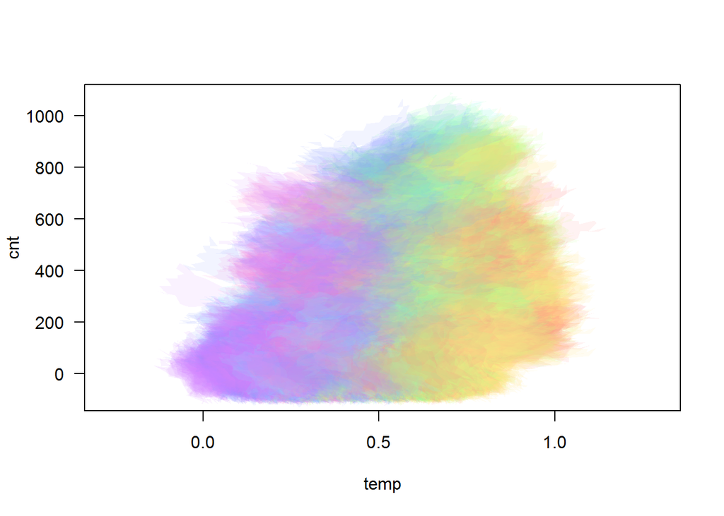

```r
month <- substr(bike$dteday, 6, 7)
month <- as.numeric(month)

koiplot(bike$temp, bike$cnt, angle=angle, cols=-sin(pi*month/12), curvature=10,
rescale_angles=F, las=1, xlab="temp", ylab="cnt")
```

```
## Choosing 10000 random rows. Change nmax to plot more rows
```

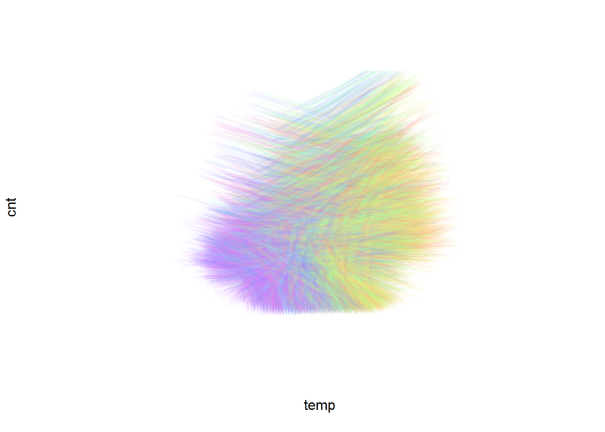

```r
koiplot(bike$temp, bike$cnt, angle=angle, cols=-sin(pi*month/12), curvature=10, width=1, height=10, rescale_angles=F, las=1, xlab="temp", ylab="cnt", xaxt="n", yaxt="n", bty="n", ylim=c(-300, max(bike$cnt)+10))
```

#### Randomness of the output

Because the brushstrokes are plotted in a random order and `xnoise` and `ynoise` are also random, the plots produced by `koiplot` are subject to some random variation. It is therefore a good idea to set the seed before running `koiplot` in order to make sure the plots are reproducible.

#### Installing the package

According to the guide [here](http://kbroman.org/pkg_primer/pages/github.html) you should be able to install the package from RStudio using the following commands.

```r
library(devtools)
install_github("rtrvale/koiplot")
```

A windows binary can also be downloaded from [here](https://github.com/rtrvale/rtrvale.github.io/tree/master/koiplot).